# programming project

Desirè Cantavenera

2025-07-10

## Introduction

This report describes the single-cell RNA-seq analysis of a 10X Genomics dataset using Seurat. The steps include gene annotation, filtering, normalization, dimensionality reduction, clustering, cell type annotation, and inference of tissue origin.

##1 upload libraries

```r
library(Seurat)
```

```r
library(ggplot2)
library(data.table)
library(dplyr)
# Carico il seurat_obj
data_dir <- "~/Desktop/programming"
sc_data <- Read10X(data.dir = data_dir)
seurat_obj <- CreateSeuratObject(counts = sc_data, project = "ExamProject")
seurat_obj
```

```
## An object of class Seurat
## 36601 features across 10194 samples within 1 assay
## Active assay: RNA (36601 features, 0 variable features)
##  1 layer present: counts
```

```r
seurat_obj <- NormalizeData(seurat_obj)
```

```
## Normalizing layer: counts
```

##2 - Task 1: Gene Annotation (Filter for protein-coding genes) # Obiettivo: filtrare solo i geni codificanti per proteine (“protein-coding”), # utilizzando il file GTF ufficiale.  
# Questo è essenziale per rimuovere trascritti non codificanti o pseudogeni, # focalizzando l’analisi solo sui trascritti funzionali.

```r
gtf_path <- "~/Desktop/programming/Homo_sapiens.GRCh38.111.gtf"
gtf <- fread(gtf_path, header = FALSE, sep = "\t", data.table = FALSE, skip = "#")
gtf_genes <- gtf[gtf[, 3] == "gene", ]
gtf_protein_coding <- gtf_genes[grep("gene_biotype \"protein_coding\"", gtf_genes[, 9]), ]
protein_coding_genes <- gsub(".*gene_name \"([^\"]+)\".*", "\\1", gtf_protein_coding[, 9])
seurat_obj <- subset(seurat_obj, features = intersect(rownames(seurat_obj), protein_coding_genes))
```

##3 - Task 2: Filtering cells based on gene expression # Obiettivo: identificare il numero di geni espressi per cellula, # contando i geni con almeno 3 UMI.  
# Questo filtro aiuta a individuare e rimuovere cellule con bassa qualità o # contaminazioni ambientali. # Il violin plot visualizza la distribuzione di questi valori nelle cellule.

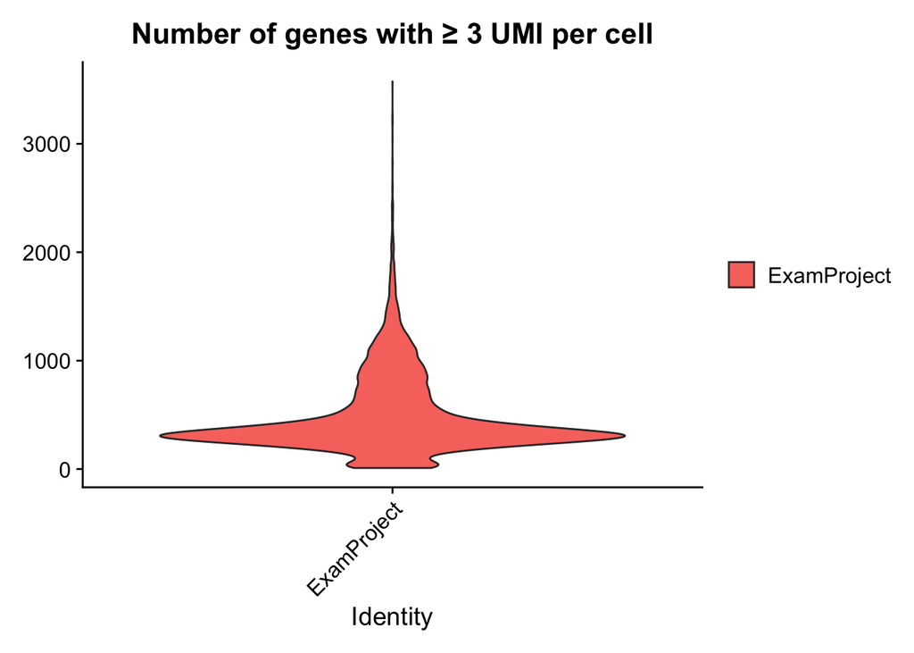

```r
counts_matrix <- GetAssayData(seurat_obj, layer = "counts")
seurat_obj$genes_umi3 <- colSums(counts_matrix >= 3)
VlnPlot(seurat_obj, features = "genes_umi3", pt.size = 0) +
  ggtitle("Number of genes with ≥ 3 UMI per cell")
```

```r
# Salva il plot
png("~/Desktop/programming/violin_genes_UMI3.png", width = 800, height = 600)
VlnPlot(seurat_obj, features = "genes_umi3", pt.size = 0) +
  ggtitle("Number of genes with ≥ 3 UMI per cell")
dev.off()
```

## 4 - Task 3: Filter unwanted gene categories

# Obiettivo: rimuovere categorie geniche non informative o potenzialmente

# confondenti come:

# - Geni mitocondriali (MT): indicano stress o apoptosi cellulare.

# - Geni ribosomiali (RP): altamente espressi e spesso tecnicamente dominanti.

# - Pseudogeni ribosomiali: simili ai RP, ma non funzionali.

# Il filtro viene effettuato con espressioni regolari basate sul nome dei geni.

# La tabella riepilogativa mostra il numero di geni rimossi per categoria.

```r
all_genes <- rownames(seurat_obj)
mito_genes <- gtf_genes[grep("MT-", gtf_genes[, 9]), ]
mito_gene_names <- gsub(".*gene_name \"([^\"]+)\".*", "\\1", mito_genes[, 9])
mito_gene_names <- mito_gene_names[mito_gene_names %in% rownames(seurat_obj)]

ribo_genes <- gtf_genes[grep("gene_name \"RP[SL][0-9]+\"", gtf_genes[, 9]), ]
ribo_gene_names <- gsub(".*gene_name \"([^\"]+)\".*", "\\1", ribo_genes[, 9])
ribo_gene_names <- ribo_gene_names[ribo_gene_names %in% rownames(seurat_obj)]

pseudo_genes <- gtf_genes[grep("gene_biotype \"pseudogene\"", gtf_genes[, 9]), ]
pseudo_gene_names <- gsub(".*gene_name \"([^\"]+)\".*", "\\1", pseudo_genes[, 9])
pseudo_gene_names <- pseudo_gene_names[pseudo_gene_names %in% rownames(seurat_obj)]

summary_table <- data.frame(
  Category = c("Mitochondrial genes", "Ribosomal genes", "Pseudogenes"),
  Removed = c(length(mito_gene_names), length(ribo_gene_names), length(pseudo_gene_names))
)
print(summary_table)
```

```
##              Category Removed
## 1 Mitochondrial genes      13
## 2     Ribosomal genes      60
## 3         Pseudogenes       0
```

```r
genes_to_remove <- unique(c(mito_gene_names, ribo_gene_names, pseudo_gene_names))
seurat_obj <- subset(seurat_obj, features = setdiff(rownames(seurat_obj), genes_to_remove))
```

##5 - Task 4: PCA and Variance Explained # Obiettivo: ridurre la dimensionalità del dataset per evidenziare la variabilità biologica più rilevante.  
# PCA viene calcolata sui geni a maggiore variabilità (PC20).  
# L’ElbowPlot aiuta a determinare il numero ottimale di componenti principali (PC) da usare.  
# L’istogramma mostra la varianza spiegata da ciascun PC: i primi PC spiegano la maggior parte della variabilità.  
# Ho deciso di usare i primi 13 PC sulla base dell’“elbow” in modo tale da includere i primi 9 PC, ma anche ulteriori altri dati fino al PC13 pur mantenendo basso il rumore di fondo.

```r
seurat_obj <- NormalizeData(seurat_obj)
```

```
## Normalizing layer: counts
```

```r
seurat_obj <- FindVariableFeatures(seurat_obj, selection.method = "vst", nfeatures = 2000)
```

```
## Finding variable features for layer counts
```

```r
seurat_obj <- ScaleData(seurat_obj)
seurat_obj <- RunPCA(seurat_obj)
```

```
## PC_ 1
## Positive:  IL32, LTB, CD3D, CD3G, IL7R, BCL11B, TCF7, CD7, ARL4C, LIME1
##     CD2, CD27, CD247, CCR7, SPOCK2, FCMR, LEF1, CD69, GZMM, MAL
##     TRABD2A, SYNE2, BCL2, ISG20, CTSW, RASGRP1, CAMK4, PEBP1, IKZF3, ITM2A
## Negative:  FCN1, FGL2, CST3, MNDA, IFI30, SERPINA1, TMEM176B, LYZ, CYBB, TYMP
##     TYROBP, CTSS, NCF2, CSTA, SPI1, IGSF6, CD68, S100A9, LST1, PSAP
##     MPEG1, GRN, CFD, TNFSF13B, AIF1, MS4A6A, S100A8, CLEC7A, DUSP6, CFP
## PC_ 2
## Positive:  MS4A1, CD79A, BANK1, SPIB, BCL11A, NIBAN3, CD79B, RALGPS2, TNFRSF13C, HLA-DQA1
##     TCF4, AFF3, CD22, BLNK, TSPAN13, PAX5, BLK, VPREB3, COBLL1, FCER2
##     FCRLA, HLA-DOB, SWAP70, GNG7, TCL1A, JCHAIN, ADAM28, FCRL1, PDLIM1, CD74
## Negative:  IL32, CD3D, CD3G, ANXA1, CD7, BCL11B, IL7R, CD2, CD247, S100A4
##     GZMM, S100A10, CTSW, TCF7, S100A6, ITGB2, LEF1, SAMHD1, MT2A, MAL
##     RORA, ID2, KLRK1, SRGN, LIME1, TRABD2A, TRAT1, GZMA, CAMK4, RGCC
## PC_ 3
## Positive:  GZMB, CLIC3, NKG7, C12orf75, CST7, GZMA, LILRA4, GNLY, CLEC4C, PRF1
##     SERPINF1, SCT, FGFBP2, KLRD1, LRRC26, DNASE1L3, HOPX, CCL5, GZMH, CTSC
##     CCL4, PACSIN1, TPM2, KLRF1, IL3RA, SPON2, TNFRSF21, MAP1A, PTCRA, SMPD3
## Negative:  MS4A1, CD79A, BANK1, TNFRSF13C, PAX5, RALGPS2, VPREB3, CD22, FCER2, FCRL1
##     CCR7, HLA-DOB, CD79B, ARHGAP24, CD24, ADAM28, P2RX5, SWAP70, CD40, FCRLA
##     FCMR, CD19, PKIG, BASP1, NCF1, FCRL2, BIRC3, BLK, TMEM154, LTB
## PC_ 4
## Positive:  LILRA4, CLEC4C, SERPINF1, SCT, LRRC26, DNASE1L3, TPM2, MAP1A, TNFRSF21, PTCRA
##     PACSIN1, SCN9A, EPHB1, SMIM5, LAMP5, CIB2, ITM2C, IL3RA, PLEKHD1, DERL3
##     SMPD3, SCAMP5, APP, PPM1J, PLD4, GAS6, ASIP, IL7R, CUX2, LEF1
## Negative:  NKG7, GNLY, CST7, KLRD1, PRF1, FGFBP2, CCL4, GZMA, HOPX, FCGR3A
##     GZMH, KLRF1, CCL5, SPON2, ADGRG1, CD160, PTGDR, TBX21, PRSS23, XCL2
##     MATK, FCRL6, LAIR2, S1PR5, IL2RB, ABI3, RHOC, KLRG1, IFITM2, C1orf21
## PC_ 5
## Positive:  CDKN1C, HES4, CTSL, BATF3, TCF7L2, CSF1R, SIGLEC10, CKB, MS4A7, CALML4
##     NAP1L1, CASP5, FCGR3A, RRAS, MS4A4A, IFITM3, NEURL1, CAMK1, GPBAR1, ABI3
##     MTSS1, LY6E, ZNF703, HMOX1, RNASET2, FAM110A, CXCL16, CXCL10, NAAA, CALHM6
## Negative:  S100A12, VCAN, ITGAM, CES1, S100A8, CYP1B1, PADI4, MGST1, MCEMP1, QPCT
##     GNLY, MEGF9, CD14, THBS1, RNASE2, KLRD1, CSF3R, RBP7, CRISPLD2, CLEC4E
##     PRF1, NKG7, FGFBP2, VNN2, S100A9, CST7, BST1, GZMB, CKAP4, RNASE6
```

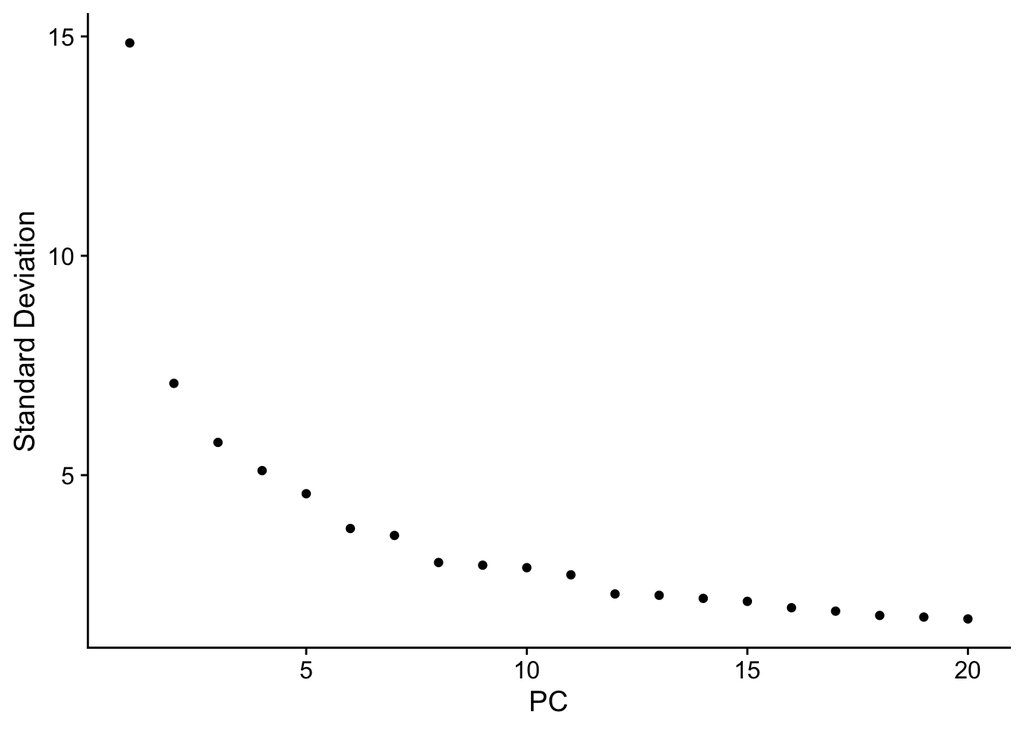

```r
ElbowPlot(seurat_obj, ndims = 20)  # mostriamo i primi 20 PC
```

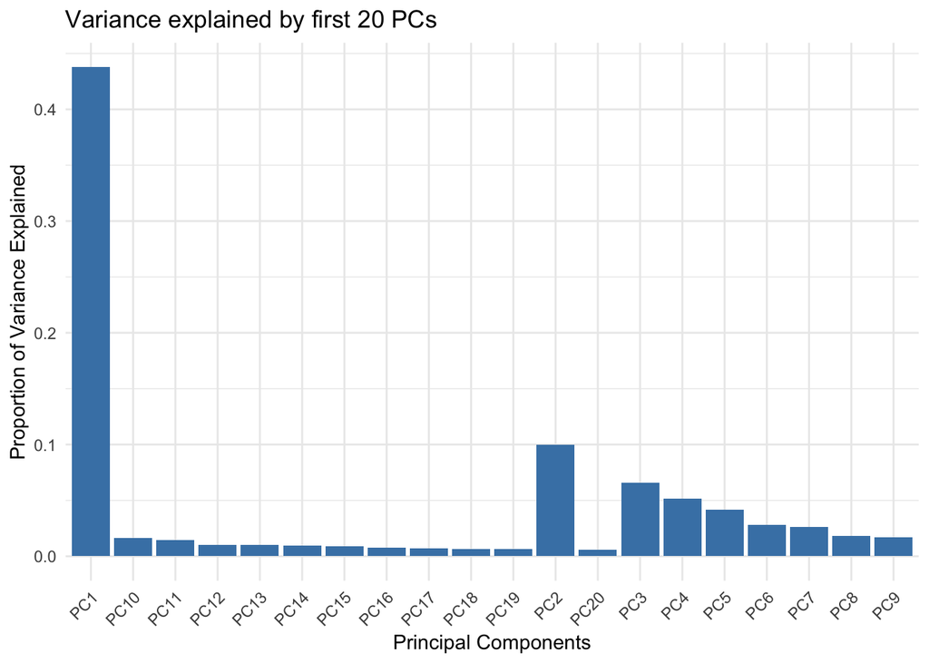

```r
pca_variance <- seurat_obj[["pca"]]@stdev^2
explained_variance <- pca_variance / sum(pca_variance)

# Crea un data frame con i primi 20 PC
var_df <- data.frame(
  PC = paste0("PC", 1:20),
  Variance = explained_variance[1:20]
)

# Istogramma con ggplot2
library(ggplot2)

ggplot(var_df, aes(x = PC, y = Variance)) +
  geom_bar(stat = "identity", fill = "steelblue") +
  theme_minimal() +
  ggtitle("Variance explained by first 20 PCs") +
  ylab("Proportion of Variance Explained") +
  xlab("Principal Components") +
  theme(axis.text.x = element_text(angle = 45, hjust = 1))
```

```r
round(explained_variance[1:20], 4)
```

```
##  [1] 0.4377 0.0998 0.0655 0.0517 0.0416 0.0284 0.0261 0.0180 0.0172 0.0166
## [11] 0.0148 0.0104 0.0101 0.0095 0.0089 0.0078 0.0072 0.0064 0.0062 0.0059
```

```r
ggsave("~/Desktop/programming/pca_variance_histogram.png", width = 8, height = 5)
```

##6 - Task 5 & 6: Clustering and UMAP # Obiettivo: visualizzare il dataset in due dimensioni preservando la struttura locale tra le cellule.  
# UMAP è una tecnica di riduzione non lineare della dimensionalità, utile per esplorare i pattern di clustering.  
# È stato usato lo stesso numero di PC determinato nell’analisi precedente (13 PC).  
# Il plot UMAP consente di osservare la separazione tra i cluster di cellule.

```r
seurat_obj <- FindNeighbors(seurat_obj, dims = 1:13)
seurat_obj <- FindClusters(seurat_obj, resolution = 0.5)
```

```
## Modularity Optimizer version 1.3.0 by Ludo Waltman and Nees Jan van Eck
##
## Number of nodes: 10194
## Number of edges: 347115
##
## Running Louvain algorithm...
## Maximum modularity in 10 random starts: 0.9142
## Number of communities: 16
## Elapsed time: 1 seconds
```

```r
seurat_obj <- RunUMAP(seurat_obj, dims = 1:13)
```

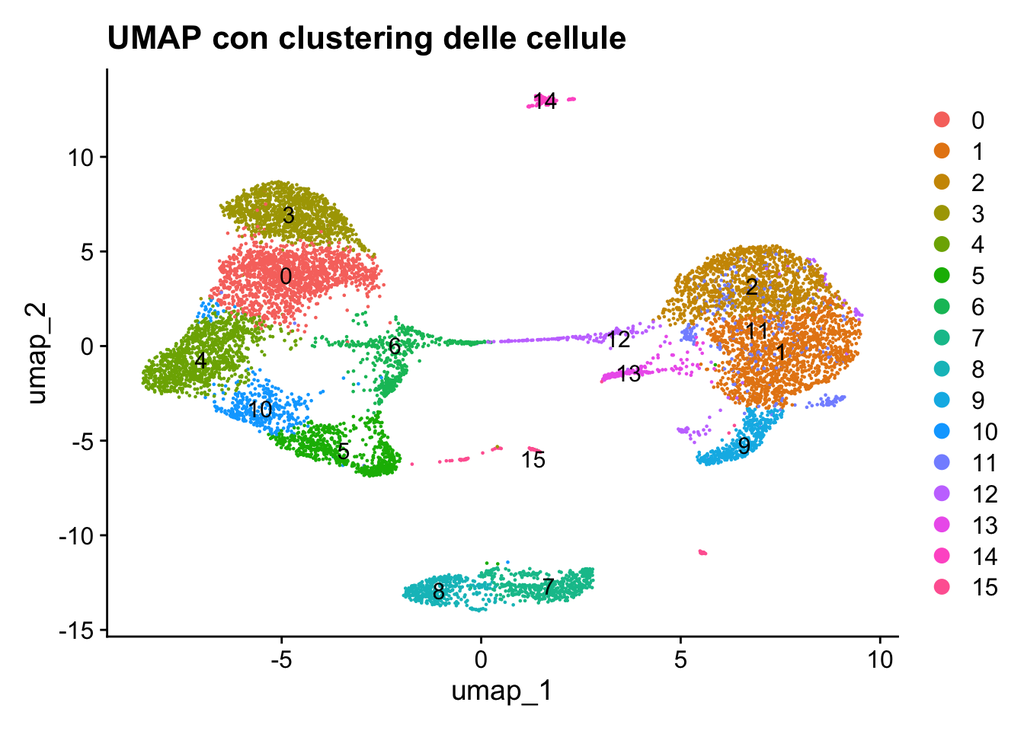

```r
library(ggplot2)
DimPlot(seurat_obj, reduction = "umap", label = TRUE) +
  ggtitle("UMAP con clustering delle cellule")
```

```r
# Obiettivo: identificare gruppi di cellule simili basati sull’espressione genica.
# È stato usato l’algoritmo di clustering Louvain, che lavora sul grafo dei vicini (kNN) calcolato sui PC.
# La risoluzione è impostata a 0.5: valori maggiori portano a più cluster.
# Sono stati identificati i marker (geni maggiormente espressi) per ogni cluster con `FindAllMarkers`.
# `top_markers` mostra il gene con logFC più alto per ogni cluster, utile per la successiva annotazione.
# I marker vengono anche visualizzati su UMAP per osservare la loro distribuzione.

markers <- FindAllMarkers(seurat_obj, only.pos = TRUE, min.pct = 0.25, logfc.threshold = 0.25)
```

[output not shown]

```r
head(markers)
```

```
##      p_val avg_log2FC pct.1 pct.2 p_val_adj cluster gene
## IL7R     0   1.337728 0.944 0.392         0       0 IL7R
## TCF7     0   1.788524 0.914 0.372         0       0 TCF7
## CCR7     0   1.912205 0.816 0.278         0       0 CCR7
## CD3G     0   1.477787 0.937 0.403         0       0 CD3G
## CD3D     0   1.244518 0.960 0.427         0       0 CD3D
## CD3E     0   1.444383 0.982 0.464         0       0 CD3E
```

```r
library(dplyr)
top_markers <- markers %>% group_by(cluster) %>% top_n(n = 1, wt = avg_log2FC)
print(top_markers)
```

```
## # A tibble: 16 × 7
## # Groups:   cluster [16]
##        p_val avg_log2FC pct.1 pct.2 p_val_adj cluster gene
##        <dbl>      <dbl> <dbl> <dbl>     <dbl> <fct>   <chr>
##  1 1.32e-239       3.37 0.277 0.041 2.46e-235 0       ADTRP
##  2 2.04e-248       3.74 0.265 0.033 3.81e-244 1       CXCL10
##  3 0               4.00 0.486 0.047 0         2       MCEMP1
##  4 0               5.03 0.3   0.024 0         3       S100B
##  5 0               3.98 0.33  0.021 0         4       TNFRSF4
##  6 0               7.18 0.441 0.007 0         5       PRSS23
##  7 3.06e-  6       3.61 0.26  0.222 5.71e-  2 6       PLCG2
##  8 0               6.81 0.57  0.007 0         7       TNFRSF13B
##  9 0               7.69 0.285 0.003 0         8       KCNG1
## 10 0               6.71 0.905 0.036 0         9       CDKN1C
## 11 0               4.96 0.754 0.044 0         10      GZMK
## 12 1.24e- 41       1.46 0.27  0.063 2.31e- 37 11      AQP9
## 13 2.75e- 14       4.17 0.379 0.221 5.13e- 10 12      PLCG2
## 14 0               8.08 0.781 0.011 0         13      FCER1A
## 15 0              10.6  0.348 0     0         14      PROC
## 16 0              11.6  0.378 0.001 0         15      TREML1
```

```r
top_markers$gene
```

```
##  [1] "ADTRP"     "CXCL10"    "MCEMP1"    "S100B"     "TNFRSF4"   "PRSS23"
##  [7] "PLCG2"     "TNFRSF13B" "KCNG1"     "CDKN1C"    "GZMK"      "AQP9"
## [13] "PLCG2"     "FCER1A"    "PROC"      "TREML1"
```

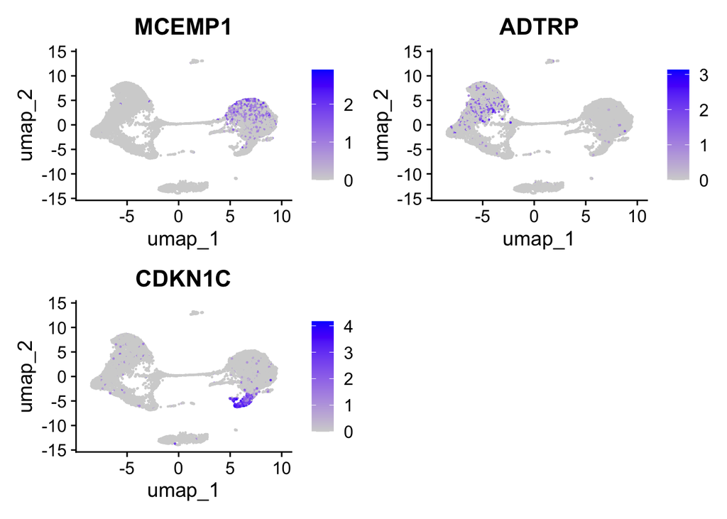

```r
FeaturePlot(seurat_obj, features = c("MCEMP1", "ADTRP", "CDKN1C"))
```

## Task 7: Cell Type Annotation

# Obiettivo: assegnare un’identità biologica ai cluster sulla base dei marker genici.

# È stata creata una mappa tra ID numerici dei cluster e nomi dei tipi cellulari basata su: